# Who Quits Smoking? Unraveling the Key Influences

Predicting Smoking Cessation Using Data and Machine Learning

Author: Mercy Atuahene

Date: March 19, 2025

# 1 Abstract

This project examines the effect of smoking cessation on weight change using clinical, socio-economic, and behavioral features. The analysis is based on the NHANES I Epidemiologic Follow-up Study (NHEFS) sample dataset. Exploratory data analysis and feature engineering were conducted to better understand variable relationships and guide model development. Regularized logistic and linear regression models were used to evaluate classification and prediction performance, with cross-validation applied to assess accuracy and generalizability. Support Vector Machines (SVM) were also implemented to compare performance with the regularized models. The results highlight how statistical learning methods, when paired with proper hyperparameter tuning, can support risk prediction and inform decision-making in clinical and public health settings.

```r
#install.packages("readxl") # install package if required
#nhefs <- read_excel("https://matuahene.github.io/STA552/Poject2/NHEFS.xls")
nhefs <-read.csv("https://matuahene.github.io/STA552/Project2/nhefs.csv", skip=0)
#str(nhefs)
#Function to Convert Variables to Factors with Labels
convert_to_factor <- function(df, var_labels) {
  for (var in names(var_labels)) {
    if (var %in% colnames(df)) {

      # Check if the variable has labels (list format) or is just a vector
      if (is.list(var_labels[[var]])) {
        labels <- var_labels[[var]]$labels   # Extract labels
        missing_values <- var_labels[[var]]$missing  # Extract missing values (if any)

        # Replace specified values with NA
        if (!is.null(missing_values)) {
          df[[var]][df[[var]] %in% missing_values] <- NA
        }
      } else {
        labels <- var_labels[[var]]  # Just a vector of labels
        missing_values <- NULL  # No missing values
      }

      # Convert to factor with labels (if labels exist)
      if (!is.null(labels)) {
        df[[var]] <- factor(df[[var]], labels = labels)
      } else {
        df[[var]] <- factor(df[[var]])  # Convert to factor without labels
      }

    } else {
      warning(paste("Variable", var, "not found in dataset"))
    }
  }
  return(df)
}

var_labels <- list(
  sex = c("Male", "Female"),
  qsmk = c("Did Not Quit", "Quit"),
  race = c("White", "Black or Other"),
  marital = c( "Married", "Widowed", "Never married", "Divorced", "Separated", "Unknown"),
  exercise = c("much exercise", "moderate exercise", "little or no exercise"),
  active = c("very active", "moderately active", "inactive"),
  alcoholfreq = c("Almost every day", "2-3 times/week", "-4 times/month", "< 12 times/year", "No alcohol last year", "Unknown"),
  alcoholpy = list(labels = c("EVER", "NEVER"),  missing = 2),
  alcoholtype = c("BEER", "WINE", "LIQUOR", "OTHER"),
  asthma = c("NEVER", "EVER"),
  bronch = c("NEVER", "EVER"),
  chroniccough = list(c("NEVER", "EVER"), missing=2),
  diabetes = list(labels =c("NEVER", "EVER"), missing=2),
  education = c("8TH GRADE OR LESS", "HS DROPOUT", "HS", "COLLEGE DROPOUT",  "COLLEGE OR MORE"),
  death = c("NO", "YES"),
  hbp = list(labels = c("NEVER", "EVER"), missing=2),
  hbpmed = list(labels = c("NEVER", "EVER"), missing=2),
  hf = c("NEVER", "EVER"),
  hightax82 = c("otherwise", "High taxed state of residence"),
  tb = c("NEVER", "EVER"),
  weakheart = c("NEVER", "EVER"),
  wtloss = c("NEVER", "EVER"),
  income = c("<$1000", "1000-1999", "2000-2999", "3000-3999", "4000-4999", "5000-5999", "6000-6999", "7000-9999", "10000-14999", "15000-19999", "20000-24999",
             "25000+")
  )

# Named list of labels
labels_list <- list(
  hf = "Heart Failure",  hbpmed = "Blood Pressure Medication in 1971",  race = "Race/Ethinicity",  age = "Age in 1971 (years)", qsmk = "Quit smoking between 1971 and 1982",
  marital = 'Marital Status', exercise = "How much exercise",  active = "How active inparticular day", alcoholfreq = "How often you drink", alcoholtype = "Type of Alcohol",
  asthma = "Asthma in 1971?", bronch = "Bronchitis/Emphysema in 1971", chroniccough ='Had Chronic cought in 1971?', diabetes = "Diabetes in 1971", education = "Amount of Education in 1971", death = "Death by 1992", hbp = "High Blood Pressure in 1971",  weakheart = "Weak Heart Meds in 1971", wt71 = 'Weight (kg) in 1971', wt82 = 'Weight (kg) in 1982',
  wt82_71 = "Weight Change in kg", wtloss = "Weight Loss?", yrdth = "Year of Death", school = "Highest Grade of Regular School in 1971", income="Total Family Income", smokeyrs = "Years of Smoking", sex = "Sex", smokeintensity = 'Number of cigarettes smoked per day in 1971', hightax82 = "Living in Highly Taxed State", cholesterol = "Cholesterol",
  price71 = "Average Tobacco price in state of residence in 1971", price82 = "Average Tobacco price in state of residence in 1982",
  price71_82 = "Difference in avg tobacco price in state of residence 1971-1982", sbp= "Systolic Blood Pressure" , dbp = "Diastolic Blood Pressure" ,
  tax71 = "Tobacco tax in 1971", tax82 = "Tobacco tax in 1982", tax71_82 = "Difference in tobacco tax in State of residence  1971-1982"
)
```

# 2 Introduction

Smoking, a modifiable behavior is also the leading preventable cause of death, disability in the US according the [(CDC)](https://www.cdc.gov/tobacco/about/index.htm). Cigarette smoking and second cause more than 480,000 deaths representing close to 1 in 5 deaths. It is known to cause many diseases such as cancer, type-2 diaberes and stroke. These outomes leads to increase in utilization of healthcare, costs work absenteeism. The literature supports the importance of quitting smoking. It is considered one of the most import steps a person can take to improve their health. Some of the benefits of quitting include improvement respiratory function and metabolism. See [Pezzuto et al, (2023)](https://pubmed.ncbi.nlm.nih.gov/38059013/). Weight gain or loss is also reported with smoking or cessation. For instance, [Smoking cessation and weight gain CFilozof et al, (2004)](https://pubmed.ncbi.nlm.nih.gov/38059013/) have reported how weight is gained upon smoke cessation in observational studies. Similar observations have also been reported when pregnant women stopped smoking. Despite the weight gain, the research also supports that the benefits outweigh the effects of smoking.

Resting on this background, we will be using the National Health and Nutrition Examination Survey Epidemiologic Follow-up Study (NHEFS) to predict the factors the contribute to one’s ability to quit smoking. We believe, the ability to identify individuals who are more likely to quit will provide an opportunity to implement targeted smoking-cessation policies that will yield effective outcomes. This will lead to reducing smoking-related illness and lead to a reduction in cost of care for smoking-related deaths if we understand factors that help individuals quit smoking. Additionally, we will predict weight change (gain) when individuals quit smoking using socioeconomic and health related variables.

The purpose is thus to develop a predictive model(s) to identify individuals likely to quit smoking using, socio-economic, demographic, behavioral factors and health data and also to predict individual weight change based on smoking habits and health-related variables. We will use Regularized Logistic and Linear Regression approaches and evaluate these models performance assessing the accuracy and overall predictive power via cross-validation approaches that ensures reliable future predictions. The cross validation methods will be used the select the optimal model. We will also compare SVM Classification and Regression models to the Regularized Classification and Regression methods using metrics like MSE, MAE for regression; accuracy, ROC-AUC for classification models.

# 3 Data Overview

## 3.1 Description of Data

The NHEFS is a national longitudinal study that was jointly initiated by the National Center for Health Statistics and the National Institute on Aging in collaboration with other agencies of the Public Health Service. The NHEFS was designed to investigate the relationships between clinical, nutritional, and behavioral factors assessed in the first National Health and Nutrition Examination Survey NHANES I and subsequent morbidity, mortality, and hospital utilization, as well as changes in risk factors, functional limitation, and institutionalization. It includes a cohort of persons 25-74 years of age who completed medical examination of the NHANES I in 1971-75. It is comprised of a series of follow-up studies, the first was conducted for all participants of the NHEFS cohort from 1971 throughout 1982. Other follow-ups were conducted in 1986, 1987 and 1992 with the same design as when it was develoeped in the 1982-1984 NHEFS with a few exceptions. For additional information, see [Epidemiologic Followup Study (NHEFS)](https://wwwn.cdc.gov/nchs/nhanes/nhefs/).

For our analysis, we will be using a subset of the dataset from **Miguel Hernan and Robin’s book - What IF** which is a cleaned dataset sample from the NHEFS used in their textbook. It contains 1629 records and 64 variables. The baseline year is the 1971-75 of the survey with follow up visits at 1982 based on participants with data about their medical history at baseline.

## 3.2 Feature Variables

The variables of interest that we will be using for our purpose will include the following features:

- **Target feature variables:** smoke cessation:qsmk (QUIT SMOKING BETWEEN 1ST QUESTIONNAIRE AND 1982, 1:YES, 0:NO) and weight change in 1982: wt82_71 (WEIGHT CHANGE IN KILOGRAMS) which is the difference in weight at baseline in 1971 and in 1982.
- **Independent feature variables**
  - active: a categorical feature - (IN YOUR USUAL DAY, HOW ACTIVE ARE YOU? IN 1971, 0:very active, 1:moderately active, 2:inactive)
  - age: a numeric feature (AGE IN 1971)
  - alcoholfreq: ordinal categorical feature - (HOW OFTEN DO YOU DRINK? IN 1971 (0: Almost every day, 1: 2-3 times/week, 2: 1-4 times/month, 3: < 12 times/year, 4: No alcohol last year, 5: Unknown) )
  - alcoholpy: categorical feature variable - (HAVE YOU HAD 1 DRINK PAST YEAR? IN 1971, (1:EVER, 0:NEVER; 2:MISSING))
  - alcoholtype: categorical feature variable -(WHICH DO YOU MOST FREQUENTLY DRINK? IN 1971 (1: BEER, 2: WINE, 3: LIQUOR, 4: OTHER/UNKNOWN))
  - asthma: categorical feature variable - (DX ASTHMA IN 1971, (1:EVER, 0:NEVER) )
  - bronch: categorical feature variable - (DX CHRONIC BRONCHITIS/EMPHYSEMA IN 1971, (1:EVER, 0:NEVER))
  - cholesterol: numeric feature variable - (SERUM CHOLESTEROL (MG/100ML) IN 1971)
  - chroniccough:categorical feature variable - (DX CHRONIC COUGH IN 1971, (1:EVER, 0:NEVER))
  - dbp: numerical feature variable - (DIASTOLIC BLOOD PRESSURE IN 1982)
  - death: categorical feature variable - (DEATH BY 1992, (1:YES, 0:NO))
  - diabetes:categorical feature variable - (DX DIABETES IN 1971, (1:EVER, 0:NEVER, 2:MISSING))
  - education: categorical, ordinal feature variable AMOUNT OF EDUCATION BY 1971 - ((1: 8TH GRADE OR LESS, 2: HS DROPOUT, 3: HS, 4:COLLEGE DROPOUT, 5: COLLEGE OR MORE))
  - exercise:categorical, ordinal feature variable -(IN RECREATION, HOW MUCH EXERCISE? IN 1971, (0:much exercise,1:moderate exercise,2:little or no exercise))
  - hbp: categorical feature variable - (DX HIGH BLOOD PRESSURE IN 1971, (1:EVER, 0:NEVER, 2:MISSING))
  - hbpmed:categorical feature variable - (USE HIGH BLOOD PRESSURE MEDICATION IN 1971, (1:EVER, 0:NEVER, ; 2:MISSING))
  - hf:categorical feature variable - (DX HEART FAILURE IN 1971, (1:EVER, 0:NEVER))
  - hightax82: categorical feature variable - (LIVING IN A HIGHLY TAXED STATE IN 1982, (High taxed state of residence=1, 0 otherwise))
  - ht: numeric feature variable - (HEIGHT IN CENTIMETERS IN 1971)
  - income:categorical, ordinal feature variable - (TOTAL FAMILY INCOME IN 1971 (11:<$1000, 12: 1000-1999, 13: 2000-2999, 14: 3000-3999, 15: 4000-4999, 16: 5000-5999, 17: 6000-6999, 18: 7000-9999, 19: 10000-14999, 20: 15000-19999, 21: 20000-24999, 22: 25000+))
  - marital: categorical feature variable - (MARITAL STATUS IN 1971 (1: Under 17, 2: Married, 3: Widowed, 4: Never married, 5: Divorced, 6: Separated, 8: Unknown))
  - price71: numeric feature variable - (AVG TOBACCO PRICE IN STATE OF RESIDENCE 1971 (US$2008))
  - price71_82:numeric feature variable - (DIFFERENCE IN AVG TOBACCO PRICE IN STATE OF RESIDENCE 1971-1982 (US$2008))
  - price82: numeric feature variable - (AVG TOBACCO PRICE IN STATE OF RESIDENCE 1982 (US$2008))
  - qsmk: categorical feature variable - ( QUIT SMOKING BETWEEN 1ST QUESTIONNAIRE AND 1982, (1:YES, 0:NO))
  - race: categorical feature variable - ( (0: WHITE 1: BLACK OR OTHER IN 1971) )
  - sbp: numeric feature variable - (SYSTOLIC BLOOD PRESSURE IN 1982)
  - school: categorical feature variable - (HIGHEST GRADE OF REGULAR SCHOOL EVER IN 1971)
  - seqn: categorical feature variable (UNIQUE PERSONAL IDENTIFIER)
  - sex: binary feature variable - ((0: MALE 1: FEMALE))
  - smokeintensity:numeric feature variable - (NUMBER OF CIGARETTES SMOKED PER DAY IN 1971)
  - smkintensity: numeric feature variable - (82_71 INCREASE IN NUMBER OF CIGARETTES/DAY BETWEEN 1971 and 1982)
  - smokeyrs:numeric feature variable - (YEARS OF SMOKING)
  - tax71: numeric feature variable - (TOBACCO TAX IN STATE OF RESIDENCE 1971 (US$2008))
  - tax71_82:numeric feature variable - (DIFFERENCE IN TOBACCO TAX IN STATE OF RESIDENCE 1971-1982 (US$2008))
  - tax82:numeric feature variable - (TOBACCO TAX IN STATE OF RESIDENCE 1971 (US$2008))
  - wt71: numeric feature variable - ( WEIGHT IN KILOGRAMS IN 1971)
  - wt82: numeric feature variable - ( WEIGHT IN KILOGRAMS IN 1982)
  - wt82_71: numeric feature variable - ( WEIGHT CHANGE IN KILOGRAMS)
  - wtloss: binary feature variable USE WEIGHT LOSS MEDICATION IN 1971, 1:EVER, 0:NEVER`

## 3.3 Descriptive Statistics/Graphs/Fetaure engineering

Next, we provide descriptive statistics of the feature variables in our sample for each of the Target variable groups.

```r
#conflicts()
#getAnywhere(select)
# Keep only selected columns
nhefs_selected <- nhefs %>% dplyr::select(qsmk, wt82_71, wtloss, wt82, tax71,wt71, tax82, tax71_82, smokeyrs, smokeintensity, yrdth,
                                          smkintensity82_71, sex, seqn, school,sbp, dbp, race, price82, price71_82, price71, marital, income, ht,
                                          hightax82, hf, hbpmed, hbp, exercise, education, diabetes, death, chroniccough, cholesterol,
                                          bronch, asthma, alcoholtype, alcoholpy, alcoholfreq, age, active, weakheart)
#str(nhefs)

#Assign labels from above to variables
nhefs_selected <- convert_to_factor(nhefs_selected, var_labels)
#install.packages("sjlabelled")
#library(sjlabelled)


# Assign labels to variables
for (var in names(labels_list)) {
  if (var %in% names(nhefs_selected)) {
    label(nhefs_selected[[var]]) <- labels_list[[var]]
  } else {
    warning(paste("Variable", var, "does not exist in the dataset."))
  }
}

library(gt)
#table(nhefs_selected$sex, useNA = "always")
#table(is.na(nhefs$wt82_71), useNA = "always")
overalltab<-table1(~wt71+wt82+wt82_71+age+race+sex+marital+school+education+smokeyrs+hf+smokeintensity+dbp+sbp+hbp+hbpmed+alcoholtype+diabetes+chroniccough+
                    income+wtloss+cholesterol+bronch+asthma+weakheart+active+exercise+alcoholfreq+tax71+tax82+hightax82+price71+price82+price71_82+tax71_82 | qsmk,
                   data=nhefs_selected,
       caption="Table 1: Descriptive Statistics stratified by smoking cessation status in year 1982 since the first questionnaire",
       footnote="Data source:NHEFS Sample Dataset", topclass="Rtable1-zebra")
#overalltab

overalltab1 <- table1(
  ~wt71+wt82+wt82_71+age+race+sex+marital+school+education+smokeyrs+hf+smokeintensity+dbp+sbp+hbp+hbpmed+alcoholtype+diabetes+chroniccough+
                    income+wtloss+cholesterol+bronch+asthma+weakheart+active+exercise+alcoholfreq+tax71+tax82+hightax82+price71+price82+price71_82+tax71_82| qsmk,
  data = nhefs_selected,
  caption = "Table 1: Descriptive Statistics stratified by smoking cessation status in year 1982 since the first questionnaire",
  footnote = "Data source: NHEFS Sample Dataset",
  topclass = "Rtable1-zebra"
)
```

```r
kable(overalltab1, caption = "Table 1: Descriptive Statistics stratified by smoking cessation status in year 1982 since the first questionnaire")
```

Table 3.1: Table 1: Descriptive Statistics stratified by smoking cessation status in year 1982 since the first questionnaire

|  | Did Not Quit | Quit | Overall |
| --- | --- | --- | --- |
|  | (N=1201) | (N=428) | (N=1629) |
| Weight (kg) in 1971 |  |  |  |
| Mean (SD) | 70.5 (15.6) | 72.6 (16.1) | 71.1 (15.7) |
| Median [Min, Max] | 68.5 [40.8, 169] | 71.3 [36.2, 137] | 69.4 [36.2, 169] |
| Weight (kg) in 1982 |  |  |  |
| Mean (SD) | 72.3 (15.6) | 76.9 (17.1) | 73.5 (16.2) |
| Median [Min, Max] | 70.3 [35.4, 132] | 74.8 [38.1, 137] | 72.1 [35.4, 137] |
| Missing | 38 (3.2%) | 25 (5.8%) | 63 (3.9%) |
| Weight Change in kg |  |  |  |
| Mean (SD) | 1.98 (7.45) | 4.53 (8.75) | 2.64 (7.88) |
| Median [Min, Max] | 2.15 [-41.3, 48.5] | 3.97 [-22.2, 47.5] | 2.60 [-41.3, 48.5] |
| Missing | 38 (3.2%) | 25 (5.8%) | 63 (3.9%) |
| Age in 1971 (years) |  |  |  |
| Mean (SD) | 42.9 (11.9) | 46.7 (12.5) | 43.9 (12.2) |
| Median [Min, Max] | 43.0 [25.0, 72.0] | 47.0 [25.0, 74.0] | 44.0 [25.0, 74.0] |
| Race/Ethinicity |  |  |  |
| White | 1024 (85.3%) | 390 (91.1%) | 1414 (86.8%) |
| Black or Other | 177 (14.7%) | 38 (8.9%) | 215 (13.2%) |
| Sex |  |  |  |
| Male | 562 (46.8%) | 237 (55.4%) | 799 (49.0%) |
| Female | 639 (53.2%) | 191 (44.6%) | 830 (51.0%) |
| Marital Status |  |  |  |
| Married | 933 (77.7%) | 346 (80.8%) | 1279 (78.5%) |
| Widowed | 70 (5.8%) | 27 (6.3%) | 97 (6.0%) |
| Never married | 76 (6.3%) | 20 (4.7%) | 96 (5.9%) |
| Divorced | 77 (6.4%) | 22 (5.1%) | 99 (6.1%) |
| Separated | 45 (3.7%) | 12 (2.8%) | 57 (3.5%) |
| Unknown | 0 (0%) | 1 (0.2%) | 1 (0.1%) |
| Highest Grade of Regular School in 1971 |  |  |  |
| Mean (SD) | 11.1 (3.00) | 11.2 (3.32) | 11.1 (3.09) |

[output cut: 117 more lines]

```r
#histograms and bar charts
library(gridExtra)

# Create histograms for weight change, price change and tax change
hist1 <- ggplot(nhefs_selected, aes(x = price71_82)) +
  geom_histogram(aes(y = ..density..), bins = 30, fill = "purple", color = "black", alpha = 0.5) +
  geom_density(color = "blue", size = 1) +  # Blue density line
  labs(title = "Diff. in avg. price Change 1982-1971 ($)", x = "Price Change ($)", y = "Density") #  not normal

hist2 <- ggplot(nhefs_selected, aes(x = tax71_82)) +
  geom_histogram(aes(y = ..density..), bins = 30, fill = "purple", color = "black", alpha = 0.5) +
  geom_density(color = "blue", size = 1) +  # Blue density line
  labs(title = "Diff. in Tobacco Tax in 1982-1972 ($)", x = "Tax Change ($)", y = "Density")

hist3<- ggplot(nhefs_selected, aes(x = wt82_71)) +
  geom_histogram(aes(y = ..density..), bins = 30, fill = "purple", color = "black", alpha = 0.5) +
  geom_density(color = "blue", size = 1) +  # Blue density line
  labs(title = "Weight Chg. 1982-1971 (kg)", x = "Weight Change (kg)", y = "Density")



den1<-ggplot(nhefs_selected, aes(x = price71_82, fill = factor(qsmk))) +scale_fill_manual(values = c("Quit" = "lightblue", "Did Not Quit" = "purple"))+
  geom_density(alpha = 0.5) +
  labs(title = "Density Plot of Change in Price of Cigarette: 1982 - 1971 (kg) by Smoking Status",
       x = "Tax Change",
       y = "Density",

       fill = "Smoking Status") +
  theme_minimal()

den2<-ggplot(nhefs_selected, aes(x = tax71_82, fill = factor(qsmk))) +scale_fill_manual(values = c("Quit" = "lightblue", "Did Not Quit" = "purple"))+
  geom_density(alpha = 0.5) +
  labs(title = "Density Plot of Tax Change: 1982-1971 by Smoking Status",
       x = "Tax Change",
       y = "Density",
       fill = "Smoking Status") +
  theme_minimal()

den3<-ggplot(nhefs_selected, aes(x = wt82_71, fill = factor(qsmk))) +scale_fill_manual(values = c("Quit" = "lightblue", "Did Not Quit" = "purple"))+
  geom_density(alpha = 0.5) +
  labs(title = "Density Plot of Weight Change : 1982 - 1971 (kg) by Smoking Status",
       x = "Tax Change",
       y = "Density",

       fill = "Smoking Status") +
  theme_minimal()


#grid.arrange(hist1, hist2,hist3, ncol=2)
#grid.arrange(den1, den2,den3, ncol=2)
```

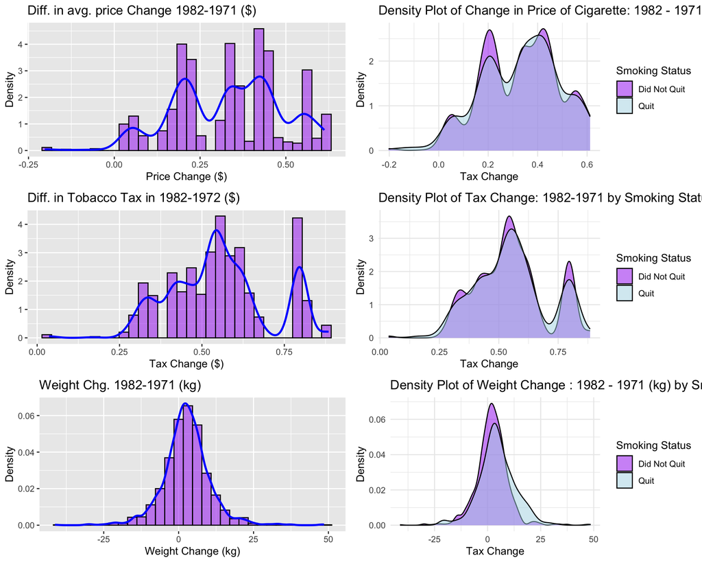

Figure 3.1: Selected Indpendent Feature Variable Plots

```r
   grid.arrange(hist1, den1,  hist2, den2, hist3, den3, ncol=2)
```

In **Figure 3.1**, only weight change from 1971 to 1982 was approximately normal, price of tobacco and associated tax did not appear normal. For instance change in tax on cigarettes shows most common tax differences are clustered between 0.4 and 0.8 dollars and is bimodal with positive skewness. The 2 feature variables that are not normal will be standardized for analysis in our model generation and predictions.

In summary,

- Price and tax increases occurred across the board from 1971 to 1982 but did not vary dramatically by smoking status.
- Weight change is the only variable showing a slight behavioral difference—quitters may have gained more weight post-cessation.

```r
#quit smoking status
smokestat_bar <- ggplot(nhefs_selected, aes(x = qsmk, fill = qsmk)) +
  geom_bar(position = "dodge", stat = "count") +
  geom_text(
    aes(label = after_stat(scales::percent(prop)), group = 1),
    stat = "prop",
    vjust = -0.5
  ) +
  labs(
    title = "Smoking Status",
    x = "Smoking Status",
    y = "Proportion",
    fill = "Smoking Status"
  ) +
  scale_fill_manual(values = c("Did Not Quit" = "maroon", "Quit" = "blue")) +
  theme_classic()


# Convert categorical variables to factors
nhefs_selected$qsmk <- as_factor(nhefs_selected$qsmk)
# Convert "smkintensity82_71" to numeric
nhefs_selected$smkintensity82_71 <- as.numeric(nhefs_selected$smkintensity82_71)
nhefs_selected$smokeyrs <- as.numeric(nhefs_selected$smokeyrs)
# Convert "age" to numeric
nhefs_selected$age <- as.numeric(nhefs_selected$age)


#feature enginner martial status

library(dplyr)

nhefs_selected <- nhefs_selected %>%
  mutate(marital_grouped = factor(case_when(
    as.character(marital) == "Married" ~ "Married",
    TRUE ~ "Others"
  ), levels = c("Married", "Others")))

#table(nhefs_selected$marital_grouped)

# smoking studys by marital status
smoke21<-ggplot(nhefs_selected, aes(x = marital_grouped, fill = qsmk)) +
  geom_bar(position = "dodge") +  # Bars placed side by side
    geom_text(
    aes(label = after_stat(scales::percent(prop)), group = 1),
    stat = "prop",
      position = position_dodge(width = 0.9),
  vjust = -0.6
  ) +
  labs(title = "Smoking Status by Grouped Marital Status", x = "Grouped Marital Status", y = "Count", fill = "Smoking Status")+
  scale_fill_manual(values = c("Did Not Quit" = "maroon", "Quit" = "blue"))


smoke2<-ggplot(nhefs_selected, aes(x = marital_grouped, y = qsmk, size = age, color = smkintensity82_71)) +
  geom_jitter(alpha = 0.7) +  # Adds random noise to avoid overplotting
  labs(title = "Smoking Status by Grouped Marital Status, Sized by Age",
       x = "Marital Status", y = "Smoking Status", color = "Increase in number of cigrettes smoked between 1971 and 1982", size = "Age")+
  scale_color_gradient(low = "lightblue", high = "darkblue")+
  coord_flip()
```

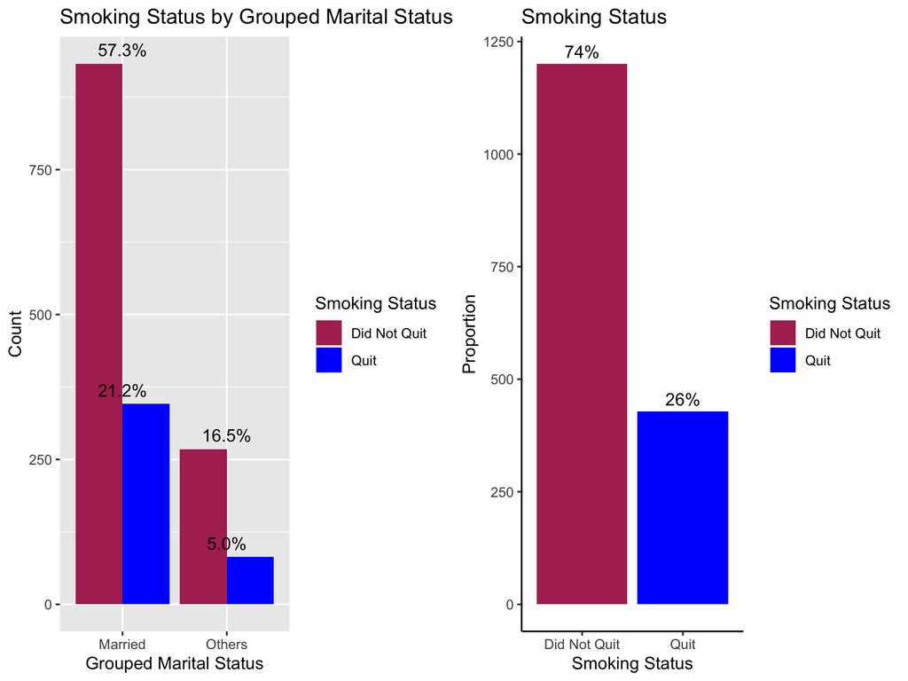

Figure 3.2: Selected Indpendent Feature Variable Plots

```r
   grid.arrange( smoke21, smokestat_bar, ncol=2)
```

```r
   smoke2
```

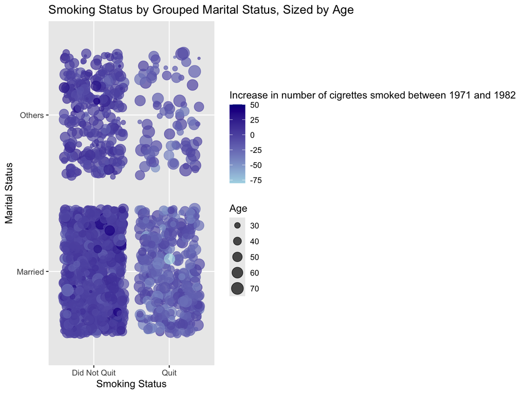

Figure 3.3: Selected Indpendent Feature Variable Plots

**Figure 3.2** show a bar plot of the number of smokers and then grouped by martial status. More people did not quit smoking compared to those who switched and most married participants were smokers in 1971. The marital status variable used here was feature engineered by grouping all non-married participants into one group to avoid having married groups with few participants.

And **Figure 3.3** bubble plot above also explores the relationship between marital status, smoking cessation, age, and historical cigarette consumption. It appears that smoking status is not strongly influenced by marital status or age alone, as all quadrants show a wide range of ages and smoking intensities. However, the density of smokers who did not quit seems higher among married individuals. Detailed analysis will help determine if these variables influence smoking cessation.

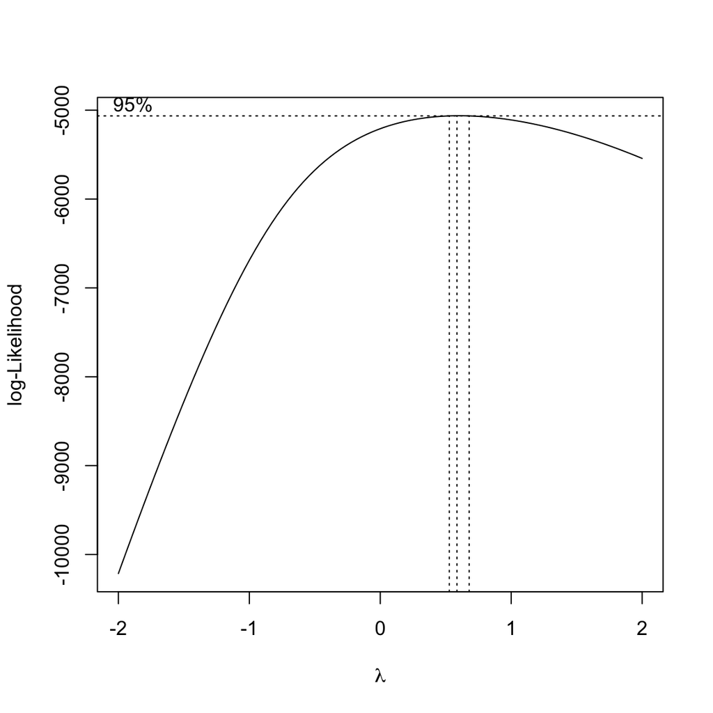

Figure 3.4: Box-Cox Transformation

```r
smokeyrs1<- ggplot(nhefs_selected, aes(x = smokeyrs)) +
  geom_histogram(aes(y = ..density..), bins = 30, fill = "purple", color = "black", alpha = 0.5) +
  geom_density(color = "blue", size = 1) +  # Blue density line
  labs(title = "Years of smoking", x = "Years", y = "Density")

# Ensure all values are positive (shift if necessary) to apply box-cox to mental health

min_value <- min(nhefs_selected$smokeyrs, na.rm = TRUE)  # Ignore NA values
if (min_value <= 0) {
  nhefs_selected$smokeyrs <- nhefs_selected$smokeyrs + abs(min_value) + 1
}

library(MASS)
# Perform Box-Cox transformation
boxcox_result <- boxcox(lm(nhefs_selected$smokeyrs ~ 1), lambda = seq(-2, 2, 0.1))  # Fit a simple model
```

```r
# Find the optimal lambda
lambda_optimal <- boxcox_result$x[which.max(boxcox_result$y)]
lambda_optimal
```

```
[1] 0.5858586
```

```r
#Apply the transformation with the optimal lambda
transformed_data <- if (lambda_optimal == 0) {
  log(transformed_data$smokeyrs)
} else {
  (nhefs_selected$smokeyrs^lambda_optimal - 1) / lambda_optimal
}

pooledData <- data.frame(OriginalData=nhefs_selected$smokeyrs, TransformedData=transformed_data)
## Reshape the data - stacking the values and assigning a variable ID.

pooledData$ID <- 1:nrow(pooledData)  # Create an ID variable
LongFormatData <- melt(pooledData, id.vars = "ID")  # Now ID is fixed

grp.col = c("navy", "darkred")
names(grp.col) = levels(LongFormatData$variable)

##
ggp = ggplot(LongFormatData,aes(x=value, fill=variable, color = variable)) +
  geom_density(alpha=0.5, na.rm = TRUE) +
  scale_color_manual(values = c("red", "blue")) +
  ggtitle("Distributions of Original and Transformed Data") +
  theme(plot.title = element_text(face = "bold", hjust = 0.5),
        legend.title = element_text(face = "bold", hjust = 0.5),
        theme(legend.position.inside = c(.9, .75)))
#
smokeyrs2 <- ggplotly(ggp)   # ggplotly's legend is always on top right by default!
smokeyrs2
```

[interactive chart not shown]

Figure 3.4: Box-Cox Transformation

```r
#add transformed data to original
nhefs_selected$smokeyrs_transformed <- transformed_data
```

Another feature engineering method was applied to income where we grouped the data into 4 groups by finding the midpoint of the income groups and using these values to group them into lowest. mid-low, High-mid and Highest groups. This also ensures more balanced groups than the individual groups.

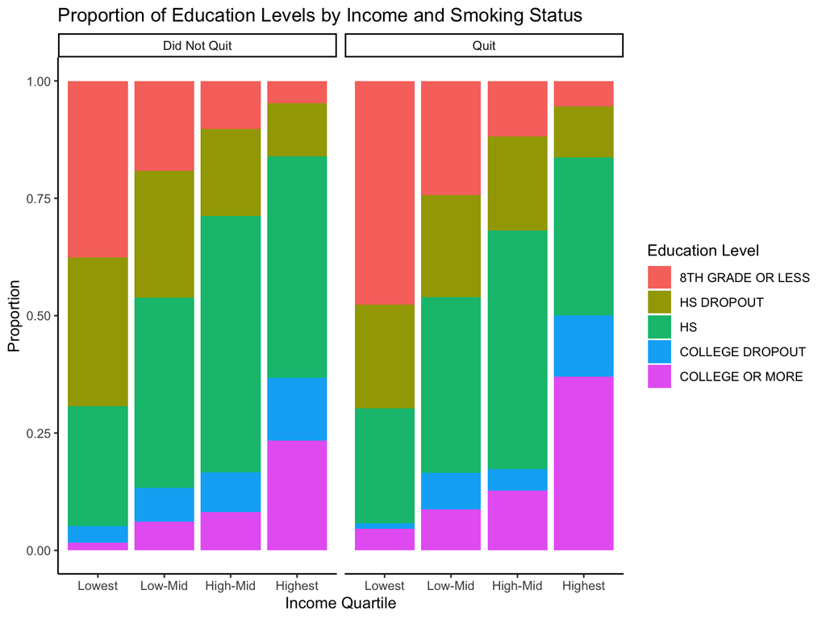

Figure 3.5: Income Feature Engineered

```r
#1. Convert the income labels into numeric values (e.g., use midpoints)
#2. Calculate quartiles
#3. Create a new variable for income quartile group

# Step 1: Make a named vector of income midpoints
income_midpoints <- c(
  "<$1000" = 500,
  "1000-1999" = 1500,
  "2000-2999" = 2500,
  "3000-3999" = 3500,
  "4000-4999" = 4500,
  "5000-5999" = 5500,
  "6000-6999" = 6500,
  "7000-9999" = 8500,
  "10000-14999" = 12500,
  "15000-19999" = 17500,
  "20000-24999" = 22500,
  "25000+" = 26000  # Approximate
)


nhefs_selected <- nhefs_selected %>%
  mutate(
    income_mid = income_midpoints[income],  # map category to midpoint
    income_quartile = ntile(income_mid, 4)  # split into 4 quartiles
  )

nhefs_selected <- nhefs_selected %>%
  mutate(income_quartile = factor(
    income_quartile,
    levels = 1:4,
    labels = c("Lowest", "Low-Mid", "High-Mid", "Highest")
  ))


library(dplyr)

ggplot(
  nhefs_selected %>%
    filter(!is.na(income_quartile), !is.na(education), !is.na(qsmk)),
  aes(x = income_quartile, fill = education)
) +
  geom_bar(position = "fill") +
  facet_wrap(~ qsmk) +
  labs(
    title = "Proportion of Education Levels by Income and Smoking Status",
    x = "Income Quartile",
    y = "Proportion",
    fill = "Education Level"
  ) +
  theme_classic()
```

```r
alcol_h <- ggplot(nhefs_selected, aes(x = alcoholtype)) +
  geom_bar(aes(fill = factor(sex)), width = 0.9, position = "dodge") +
  facet_wrap(~ qsmk) +
  labs(
    title = "Type of Alcohol Drank in 1971",
    x = "Type of Alcohol",
    y = "Count",  # or "Percent" if you're using proportions
    fill = "Sex"
  )+
  scale_fill_manual(
    values = c("Male" = "steelblue", "Female" = "firebrick"),
  ) +
  theme_classic()

#alcol_h

# Example: Grouped bar chart, facet by smoking status
race_sex <- ggplot(nhefs_selected, aes(x = race, fill = factor(sex))) +
  geom_bar(position = "dodge") +scale_fill_manual(values = c("Male" = "steelblue", "Female" = "firebrick"))+
  facet_wrap(~ qsmk) +
  labs(
    title = "Sex by Race and Smoking Cessation Status",
    x = "Race",
    y = "Count",
    fill = "Gender"
  ) +
  theme_minimal()

#race_sex

price<-ggplot(nhefs_selected, aes(x = tax71_82, y = wt82_71, color = factor(qsmk))) +
  geom_point(size = 3, alpha = 0.8) +
  labs(
    title = "Price in 1971 vs. Price in 1982 by Smoking Status",
    x = "Price in 1971",
    y = "Price in 1982",
    color = "Smoking Status"
  )+
  scale_color_manual(values = c("Quit" = "blue", "Did Not Quit" = "brown"))+
  geom_abline(slope = 1, intercept = 0, linetype = "dashed", color = "red") +
  theme_minimal()
#price

tax<-ggplot(nhefs_selected, aes(x = tax71_82, y = wt82_71, color = factor(qsmk))) +
  geom_point(size = 3, alpha = 0.8) +
  labs(
    title = "Price in 1971 vs. Price in 1982 by Smoking Status",
    x = "Price in 1971",
    y = "Price in 1982",
    color = "Smoking Status"
  )+
  scale_color_manual(values = c("Quit" = "blue", "Did Not Quit" = "brown"))+
  geom_abline(slope = 1, intercept = 0, linetype = "dashed", color = "red") +
  theme_minimal()
#tax


weight<-ggplot(nhefs_selected, aes(x = price71_82, y = wt82_71, color = factor(qsmk))) +
  geom_point(size = 3, alpha = 0.8) +
  labs(
    title = "Tax of tobacco in 1971 vs. Tax of tobacco in 1982 by Smoking Status",
    x = "Tax in 1971",
    y = "Tax in 1982",
    color = "Smoking Status"
  )+ scale_fill_manual(values = c("Quit" = "blue", "Did Not Quit" = "brown"))+
  geom_abline(slope = 1, intercept = 0, linetype = "dashed", color = "red") +
  theme_minimal()
#weight


# Create a unique id for each observation and convert price variables to numeric
data_long <- nhefs_selected %>%
  dplyr::select(qsmk, price71, price82) %>%
  mutate(across(c(price71, price82), as.numeric)) %>%
  mutate(id = row_number()) %>%  # Create unique identifier for each row
  pivot_longer(
    cols = c(price71, price82),
    names_to = "year",
    values_to = "price"
  )


sex_smoke<-ggplot(nhefs_selected, aes(x = factor(sex), y = smokeintensity, fill = factor(sex))) +
  geom_boxplot() +
  labs(
    title = "Smoking Intensity in 1971 by Sex",
    x = "Sex",
    y = "Cigarettes per Day",
    fill = "Sex"
  ) +
  scale_fill_manual(values = c("Male" = "skyblue", "Female" = "pink"), labels = c("Male", "Female")) +
  theme_classic()

#sex_smoke
```

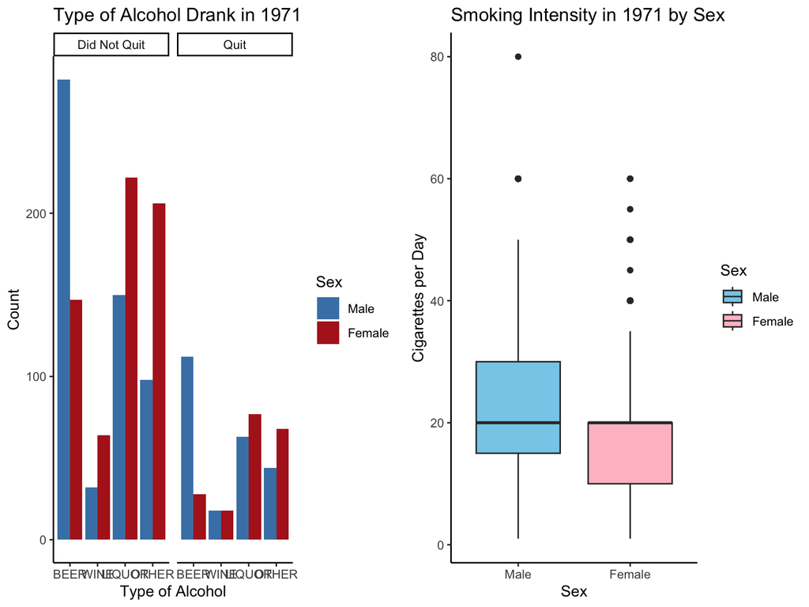

```r
   grid.arrange(alcol_h,  sex_smoke, ncol=2)
```

In the smoking intensity boxplot, it shows that in 1971, males smoked more cigarettes per day than females on average. Males also had more variability in their smoking behavior, including some extreme outliers with very high cigarette use. Females had lower and more consistent smoking intensity, suggesting a potential gender-based difference in smoking patterns during that time period.

# 4 Multilple Imputation

To preserve the sample size and minimize bias, multiple imputation was applied to the NHEFS dataset. This approach allows for more accurate estimation by accounting for the uncertainty associated with missing data, ultimately leading to more reliable and valid results.Continuous variables were imputed using predictive mean matching (PMM), which maintains the original distribution and avoids unrealistic values. Categorical variables were imputed using logistic or multinomial regression, depending on the number of categories, to ensure consistency with their underlying structure. The first of the five multiply imputated datasets was used for further analysis.

```r
#implement MICE

analytic_dset <- nhefs_selected [,
                                       c("qsmk", "wt82_71", "age","race", "sex", "marital", "school", "education",
                                        "smokeyrs", "hf", "smokeintensity",  "dbp","sbp","hbp", "hbpmed", "alcoholtype", "diabetes", "chroniccough",
                                       "income", "wtloss", "cholesterol", "bronch", "asthma", "weakheart", "active",
                                       "exercise", "alcoholfreq", "tax71", "tax82", "hightax82" , "price71" , "price82", "tax71_82", "price71_82",
                                       "marital_grouped", "income_quartile", "smokeyrs_transformed")]

final_analytic_dset <-analytic_dset %>%

  dplyr::select(qsmk, wt82_71, age, race, sex, marital, school, education, smokeyrs, hf, smokeintensity, dbp, sbp, hbp, hbpmed, alcoholtype, diabetes,
                chroniccough,income, wtloss, cholesterol, bronch, asthma, weakheart, active, exercise, alcoholfreq, tax71, tax82, hightax82, price71, price82,
                tax71_82, price71_82, marital_grouped, income_quartile, smokeyrs_transformed) %>%

  mutate(across(c(wt82_71, age,  smokeyrs, hf, smokeintensity, dbp, sbp, hbp, cholesterol, tax71, tax82, hightax82, price71, price82, tax71_82, price71_82,
                  smokeyrs_transformed), as.numeric),
         across(c(hf, school,hbp, alcoholtype, marital_grouped, income_quartile),as.factor))


imp5 <- mice(final_analytic_dset, method = c("logreg", "pmm", "pmm", "logreg","logreg","polyreg", "polyreg", "polyreg", "pmm", "logreg", "pmm", "pmm","pmm",

                                             "logreg", "polyreg", "polyreg","polyreg", "logreg", "polyreg","polyreg", "pmm", "pmm", "logreg", "logreg", "polyreg",
                                             "polyreg","polyreg", "pmm", "pmm", "pmm", "pmm", "pmm", "pmm", "pmm", "logreg", "polyreg", "pmm"),

                             maxit = 10,  # iterating 10 cycles to complete each imputed data set
                              m = 5,       # generate 5 imputed data set
                              seed = 134,
                              print=F)     # suppress printouts

first_imputed_data <- complete(imp5, 1)
#summary(first_imputed_data)  # Check for missing values
#str(first_imputed_data)      # Ensure correct data types
#md.pattern(final_analytic_dset)  # Visualize missing data pattern
```

```r
#first_imputed_data
saveRDS(first_imputed_data, "proj2_analytic_data.rds")
saveRDS(imp5, "imp5.rds")
```

# 5 Pincipal Components Analysis

As a result of the high dimensionality of our dataset and the presence of multicollinearity among variables (e.g., price/tax/weight in 1971 and weight/price/tax in 1982, blood pressure measures, etc), Principal Component Analysis (PCA) was performed to reduce redundancy and summarize the data more efficiently ensuring that the original correlated variables are transformed into a smaller set of uncorrelated components that capture the majority of the variance in the data. This step helps improve model performance.

```r
#first_imputed_data
final <-  readRDS("proj2_analytic_data.rds")
#class(final)

# Select only numerical columns for PCA
num_vars <- final[, sapply(final, is.numeric)]

#remove numeric outcome
num_vars <- num_vars[, !(names(num_vars) %in% "wt82_71")]

#summary(num_vars)

# Standardize the data (important for PCA) -
num_vars_scaled <- scale(num_vars)

# Perform PCA
pca_result <- prcomp(num_vars_scaled, center = TRUE, scale. = TRUE)

# Summary of PCA
cat("PCA results showing variance explained by each PC:\n")
```

```
PCA results showing variance explained by each PC:
```

```r
summary(pca_result)
```

```
Importance of components:
                          PC1    PC2    PC3    PC4     PC5     PC6     PC7
Standard deviation     2.0822 1.7471 1.3300 1.2092 1.00267 0.94411 0.64089
Proportion of Variance 0.3097 0.2180 0.1264 0.1044 0.07181 0.06367 0.02934
Cumulative Proportion  0.3097 0.5277 0.6541 0.7585 0.83032 0.89399 0.92333
                           PC8     PC9    PC10    PC11   PC12    PC13     PC14
Standard deviation     0.59541 0.52968 0.44955 0.39929 0.2619 0.09035 0.005883
Proportion of Variance 0.02532 0.02004 0.01444 0.01139 0.0049 0.00058 0.000000
Cumulative Proportion  0.94865 0.96869 0.98313 0.99452 0.9994 1.00000 1.000000
```

```r
#plot(pca_result, type = "l", main = "Scree Plot")
```

We first ensured standardization of the variables to ensure comparability across different scales. The first few principal components explained a significant proportion of the total variance, allowing us to retain key information while reducing the number of input variables. The scree plot in **Figure 5.1** , shows that the first few principal components explain most of the variation in the dataset. The first two components alone account for over 50% of the total variance, while the first four components explain more than 75%. There is a visible “elbow” at around the third or fourth component, suggesting that retaining the first 3–4 components would be a good balance between dimensionality reduction and information preservation. We made the decision to include the 5th component capturing over 80% of the variance in the data.

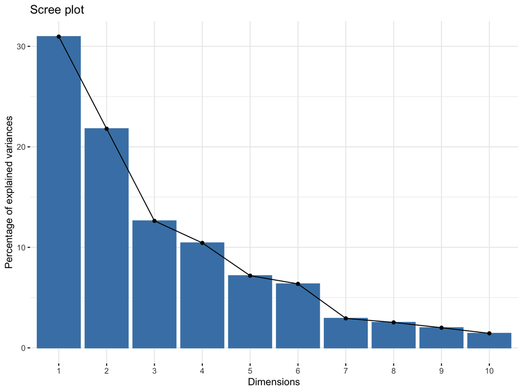

Figure 5.1: Scree Plot from PCA summary

```r
# Scree plot to visualize variance explained
library(ggplot2)
#install.packages("factoextra")  # Install the package
library(factoextra)  # Load the package

fviz_eig(pca_result)
```

```r
#summary(pca_result)
cat("Top contributing PCS explaing greater than 75% variance (eigen values greater than 1):\n")
```

```
Top contributing PCS explaing greater than 75% variance (eigen values greater than 1):
```

```r
eigenvalues <- (pca_result$sdev)^2
eigenvalues #5 eigen values greater than 1 and explains >75% variance
```

```
 [1] 4.335606e+00 3.052467e+00 1.769009e+00 1.462105e+00 1.005350e+00
 [6] 8.913359e-01 4.107434e-01 3.545098e-01 2.805611e-01 2.020943e-01
[11] 1.594330e-01 6.858854e-02 8.162388e-03 3.461299e-05
```

```r
#pca scores
pc_scores <- pca_result$x

# Add to original imputed dataset
combined_data <- cbind(final, pc_scores)
```

A plot of the pcloadings for the firs 5 components is provided in **Figure 5.2**. This helped us to get a general team of the variables contributing to the components in order to rename the PCS appropriately. The plots a summary of the feature components are provided below.

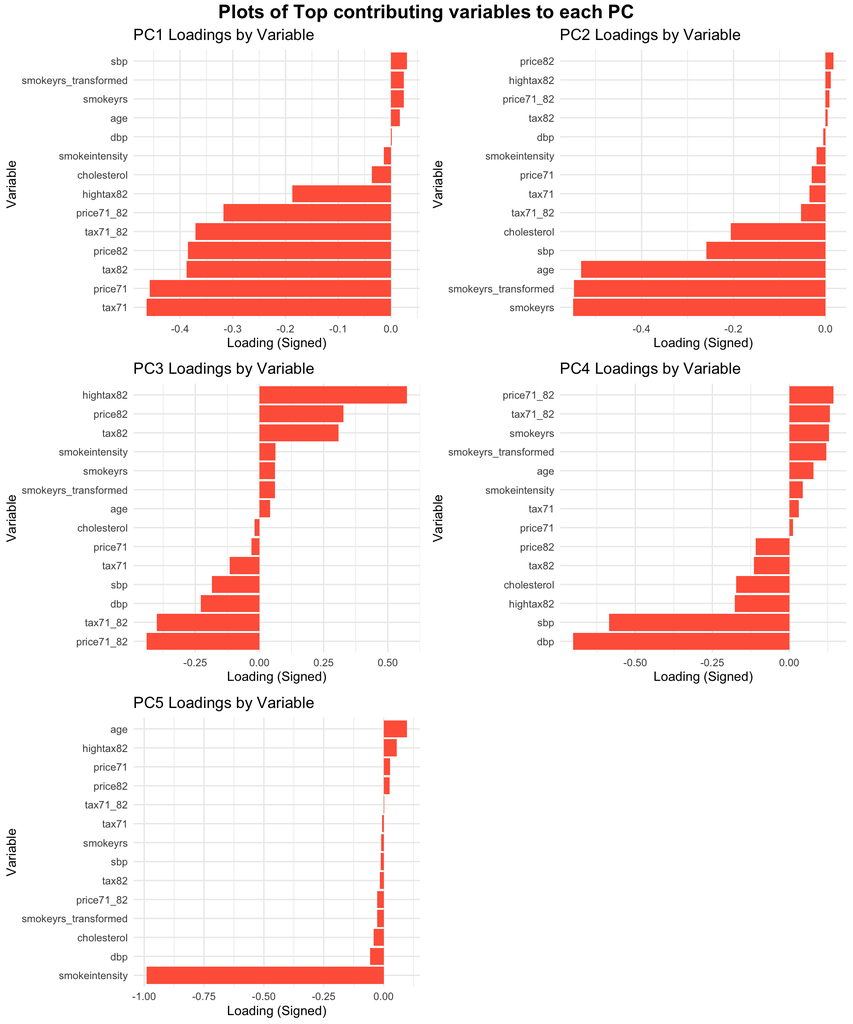

Figure 5.2: Variable Loadings from PCA analysis

```r
# Top contributors to PC1 (signed)

#loadings for pc1 and sorting the absolut values for plot to get the most contributing variables
loadings_pc1 <- pca_result$rotation[, 1]  # PC1 is the first column
abs_loadings_pc1 <- abs(loadings_pc1)
sorted_pc1 <- sort(abs_loadings_pc1, decreasing = TRUE)
top_pc1 <- data.frame(Variable = names(sorted_pc1), Loading = sorted_pc1)
#cat("Top contributing variables to PC1:\n")
#top_pc1

loadings_pc2 <- pca_result$rotation[, 2]  # PC2 is the first column
abs_loadings_pc2 <- abs(loadings_pc2)
sorted_pc2 <- sort(abs_loadings_pc2, decreasing = TRUE)
top_pc2 <- data.frame(Variable = names(sorted_pc2), Loading = sorted_pc2)
#cat("Top contributing variables to PC2:\n")
#top_pc2

loadings_pc3 <- pca_result$rotation[, 3]  # PC3 is the first column
abs_loadings_pc3 <- abs(loadings_pc3)
sorted_pc3 <- sort(abs_loadings_pc3, decreasing = TRUE)
top_pc3 <- data.frame(Variable = names(sorted_pc3), Loading = sorted_pc3)
#cat("Top contributing variables to PC3:\n")
#top_pc3

loadings_pc4 <- pca_result$rotation[, 4]  # PC3 is the first column
abs_loadings_pc4 <- abs(loadings_pc4)
sorted_pc4 <- sort(abs_loadings_pc4, decreasing = TRUE)
top_pc4 <- data.frame(Variable = names(sorted_pc4), Loading = sorted_pc4)
#cat("Top contributing variables to PC4:\n")
#top_pc4

loadings_pc5 <- pca_result$rotation[, 5]  # PC3 is the first column
abs_loadings_pc5 <- abs(loadings_pc5)
sorted_pc5 <- sort(abs_loadings_pc5, decreasing = TRUE)
top_pc5 <- data.frame(Variable = names(sorted_pc5), Loading = sorted_pc5)
#cat("Top contributing variables to PC4:\n")
#top_pc5




#plot signed versions
# Get the PC1 loadings (signed) - no absolute version
loadings_pc1 <- pca_result$rotation[, 1]
# Put into a data frame
pc1_df <- data.frame(
  Variable = names(loadings_pc1),
  Loading = loadings_pc1
)


pc1_load_plot <- ggplot(pc1_df, aes(x = reorder(Variable, Loading), y = Loading)) +
  geom_col(fill = "tomato") +
  coord_flip() +
  labs(
    title = "PC1 Loadings by Variable",
    x = "Variable",
    y = "Loading (Signed)"
  ) +
  theme_minimal()

# Get the PC2 loadings (signed) - no absolute version
loadings_pc2 <- pca_result$rotation[, 2]
# Put into a data frame
pc2_df <- data.frame(
  Variable = names(loadings_pc2),
  Loading = loadings_pc2
)


pc2_load_plot<-ggplot(pc2_df, aes(x = reorder(Variable, Loading), y = Loading)) +
  geom_col(fill = "tomato") +
  coord_flip() +
  labs(
    title = "PC2 Loadings by Variable",
    x = "Variable",
    y = "Loading (Signed)"
  ) +
  theme_minimal()


# Get the PC3 loadings (signed) - no absolute version
loadings_pc3 <- pca_result$rotation[, 3]
# Put into a data frame
pc3_df <- data.frame(
  Variable = names(loadings_pc3),
  Loading = loadings_pc3
)


pc3_load_plot <- ggplot(pc3_df, aes(x = reorder(Variable, Loading), y = Loading)) +
  geom_col(fill = "tomato") +
  coord_flip() +
  labs(
    title = "PC3 Loadings by Variable",
    x = "Variable",
    y = "Loading (Signed)"
  ) +
  theme_minimal()


# Get the PC4 loadings (signed) - no absolute version
loadings_pc4 <- pca_result$rotation[, 4]
# Put into a data frame
pc4_df <- data.frame(
  Variable = names(loadings_pc4),
  Loading = loadings_pc4
)

pc4_load_plot <- ggplot(pc4_df, aes(x = reorder(Variable, Loading), y = Loading)) +
  geom_col(fill = "tomato") +
  coord_flip() +
  labs(
    title = "PC4 Loadings by Variable",
    x = "Variable",
    y = "Loading (Signed)"
  ) +
  theme_minimal()



# Get the PC5 loadings (signed) - no absolute version
loadings_pc5 <- pca_result$rotation[, 5]
# Put into a data frame
pc5_df <- data.frame(
  Variable = names(loadings_pc5),
  Loading = loadings_pc5
)


pc5_load_plot <- ggplot(pc5_df, aes(x = reorder(Variable, Loading), y = Loading)) +
  geom_col(fill = "tomato") +
  coord_flip() +
  labs(
    title = "PC5 Loadings by Variable",
    x = "Variable",
    y = "Loading (Signed)"
  ) +
  theme_minimal()

#set all plots

grid.arrange(
  pc1_load_plot, pc2_load_plot, pc3_load_plot, pc4_load_plot, pc5_load_plot,ncol=2,
   top = textGrob("Plots of Top contributing variables to each PC",  gp = gpar(fontsize = 16, fontface = "bold"))
)
```

```r
colnames(pc_scores)[1:5] <- c(
  "price_n_taxes",
  "patient_kters",
  "price_vs_ktics",
  "health_vs_price",
  "smokeint_vs_age"
)

#add new pc variables to data for use
# Add to original imputed dataset
combined_data <- cbind(combined_data, pc_scores[, 1:5])
#summary(combined_data)

#check correlation of transformed values
check_corr<-ggplot(combined_data, aes(x = price_n_taxes, y = health_vs_price)) +
  geom_point(alpha = 0.6) +
  labs(title = "PC1 vs PC4", x = "Price & Taxes", y = "Health vs Price")


#cat("Correlation of top 5 PCs with the outcome variable:\n")
#cor(combined_data[, c("price_n_taxes", "patient_kters", "price_vs_ktics", "smokeint_vs_age", "wt82_71")])
```

The derived principal component scores were added as new features to our model for analysis.